# Unsupervised Learning (ISL 12)

Biostat 212A

Author

Dr. Jin Zhou @ UCLA

Published

March 17, 2026

Credit: This note heavily uses material from the books [*An Introduction to Statistical Learning: with Applications in R*](https://www.statlearning.com/) (ISL2) and [*Elements of Statistical Learning: Data Mining, Inference, and Prediction*](https://hastie.su.domains/ElemStatLearn/) (ESL2).

Display system information for reproducibility.

**R**

```r
rm(list = ls())
```

```r
library(recipes)
library(ggplot2)
library(embed)
library(tidymodels)
library(ISLR2)
library(tibble)

## In order to use MNIST datasets, I installed the keras package and its dependencies
# set up Tools -> Global Options -> Python -> "~/.virtualenvs/r-tensorflow/bin/python"
# reticulate::py_install("IPython")
# reticulate::py_install("tensorflow")
library(keras)
```

**Python**

```python
import IPython
print(IPython.sys_info())
```

```
{'commit_hash': '5ed988a91',
 'commit_source': 'installation',
 'default_encoding': 'utf-8',
 'ipython_path': '/Users/jinjinzhou/.virtualenvs/r-tensorflow/lib/python3.10/site-packages/IPython',
 'ipython_version': '8.33.0',
 'os_name': 'posix',
 'platform': 'macOS-15.7.4-arm64-arm-64bit',
 'sys_executable': '/Users/jinjinzhou/.virtualenvs/r-tensorflow/bin/python',
 'sys_platform': 'darwin',
 'sys_version': '3.10.16 (main, Mar  3 2025, 20:01:33) [Clang 16.0.0 '
                '(clang-1600.0.26.6)]'}
```

## 1 Overview

- Most of this course focuses on **supervised learning** methods such as regression and classification.
- In that setting we observe both a set of features $X_1,X_2,...,X_p$ for each object, as well as a response or outcome variable $Y$ . The goal is then to predict $Y$ using $X_1,X_2,...,X_p$.
- In this lecture we instead focus on **unsupervised learning**, we where observe only the features $X_1,X_2,...,X_p$. We are not interested in prediction, because we do not have an associated response variable $Y$.

### 1.1 Goals of unsupervised learning

- The goal is to discover interesting things about the measurements: is there an informative way to visualize the data? Can we discover subgroups among the variables or among the observations?
- We discuss two methods:
  - **principal components analysis**, a tool used for data visualization or data pre-processing before supervised techniques are applied, and
  - **clustering**, a broad class of methods for discovering unknown subgroups in data.

### 1.2 Challenge of unsupervised learning

- Unsupervised learning is more subjective than supervised learning, as there is no simple goal for the analysis, such as prediction of a response.
- But techniques for unsupervised learning are of growing importance in a number of fields:
  - subgroups of breast cancer patients grouped by their gene expression measurements,
  - groups of shoppers characterized by their browsing and purchase histories,
  - movies grouped by the ratings assigned by movie viewers.

### 1.3 Another advantage

- It is often easier to obtain **unlabeled data** — from a lab instrument or a computer — than **labeled data**, which can require human intervention.
- For example it is difficult to automatically assess the overall sentiment of a movie review: is it favorable or not?

## 2 Principal Components Analysis (PCA)

- PCA produces a low-dimensional representation of a dataset. It finds a sequence of linear combinations of the variables that have maximal variance, and are mutually uncorrelated.
- Apart from producing derived variables for use in supervised learning problems, PCA also serves as a tool for data visualization.
- The first **principal component** of a set of features $X_1,X_2,...,X_p$ is the normalized linear combination of the features
  $$Z_1 = \phi_{11} X_1 + \phi_{21} X_2 + \cdots + \phi_{p1} X_p$$
  that has the largest variance. By **normalized**, we mean that $\sum_{j=1}^p \phi_{j1}^2 = 1$.
- We refer to the elements $\phi_{11}, \ldots, \phi_{p1}$ as the **loadings** of the first principal component; together, the loadings make up the principal component loading vector, $\phi_1 = (\phi_{11}, \ldots, \phi_{p1})$.
- We constrain the loadings so that their sum of squares is equal to one, since otherwise setting these elements to be arbitrarily large in absolute value could result in an arbitrarily large variance.

[figure not shown]

Figure 1: The population size (`pop`) and ad spending (`ad`) for 100 different cities are shown as purple circles. The green solid line indicates the first principal component, and the blue dashed line indicates the second principal component.

### 2.1 Computation of PCs

- Suppose we have an $n \times p$ data set $\boldsymbol{X}$. Since we are only interested in variance, we assume that each of the variables in $\boldsymbol{X}$ has been centered to have mean zero (that is, the column means of $\boldsymbol{X}$ are zero).
- We then look for the linear combination of the sample feature values of the form
  $$z_{i1} = \phi_{11} x_{i1} + \phi_{21} x_{i2} + \cdots + \phi_{p1} x_{ip}
  \tag{1}$$
  for $i=1,\ldots,n$ that has largest sample variance, subject to the constraint that $\sum_{j=1}^p \phi_{j1}^2 = 1$.
- Since each of the $x_{ij}$ has mean zero, then so does $z_{i1}$ (for any values of $\phi_{j1}$). Hence the sample variance of the $z_{i1}$ can be written as $\frac{1}{n} \sum_{i=1}^n z_{i1}^2$.
- Plugging in (Equation 1) the first principal component loading vector solves the optimization problem
  $$\max_{\phi_{11},\ldots,\phi_{p1}} \frac{1}{n} \sum_{i=1}^n \left( \sum_{j=1}^p \phi_{j1} x_{ij} \right)^2 \text{ subject to } \sum_{j=1}^p \phi_{j1}^2 = 1.$$
- This problem can be solved via a [singular-value decomposition (SVD)](https://en.wikipedia.org/wiki/Singular_value_decomposition#:~:text=In%20linear%20algebra%2C%20the%20singular,matrix.) of the matrix $\boldsymbol{X}$, a standard technique in linear algebra.
- We refer to $Z_1$ as the first principal component, with realized values $z_{11}, \ldots, z_{n1}$.

### 2.2 Matrix/vector form of PCA

The element-wise formulation above is the same as the following matrix/vector version, which is more compact and connects directly to standard linear algebra tools.

**Translating the score formula.** The scalar formula $z_{i1} = \sum_{j=1}^p \phi_{j1} x_{ij}$ for all $i = 1,\ldots,n$ simultaneously is just a matrix-vector product. Stack all scores into a vector and write:

$$\mathbf{z}_1 = \boldsymbol{X} \boldsymbol{\phi}_1,$$

where $\boldsymbol{X}$ is $n \times p$ (centered), $\boldsymbol{\phi}_1$ is $p \times 1$, and $\mathbf{z}_1$ is the $n \times 1$ vector of scores $(z_{11}, \ldots, z_{n1})^T$.

**Translating the optimization.** The sample variance of the scores is

$$\frac{1}{n}\sum_{i=1}^n z_{i1}^2 = \frac{1}{n}\mathbf{z}_1^T \mathbf{z}_1 = \frac{1}{n}\boldsymbol{\phi}_1^T \boldsymbol{X}^T \boldsymbol{X} \boldsymbol{\phi}_1 = \boldsymbol{\phi}_1^T \boldsymbol{S} \boldsymbol{\phi}_1,$$

where $\boldsymbol{S} = \frac{1}{n}\boldsymbol{X}^T \boldsymbol{X}$ is the $p \times p$ sample covariance matrix (recall that $\boldsymbol{X}$ is already centered). The unit-norm constraint $\sum_j \phi_{j1}^2 = 1$ becomes $\boldsymbol{\phi}_1^T \boldsymbol{\phi}_1 = 1$.

So the scalar optimization problem is, in matrix form:

$$\max_{\boldsymbol{\phi}_1} \; \boldsymbol{\phi}_1^T \boldsymbol{S} \boldsymbol{\phi}_1 \quad \text{subject to} \quad \boldsymbol{\phi}_1^T \boldsymbol{\phi}_1 = 1.$$

**Connection to eigenvalues.** Using a Lagrange multiplier $\lambda$ for the constraint, the first-order condition is:

$$\boldsymbol{S}\boldsymbol{\phi}_1 = \lambda \boldsymbol{\phi}_1.$$

This says $\boldsymbol{\phi}_1$ must be an **eigenvector** of the covariance matrix $\boldsymbol{S}$, with eigenvalue $\lambda$. Since the objective at the solution is $\boldsymbol{\phi}_1^T \boldsymbol{S} \boldsymbol{\phi}_1 = \lambda$, the maximum is achieved by choosing $\boldsymbol{\phi}_1$ as the eigenvector corresponding to the **largest** eigenvalue $\lambda_1$. This eigenvalue *is* the variance of the first PC.

Similarly, $\boldsymbol{\phi}_2$ is the eigenvector with the second-largest eigenvalue, and so on. In general, the $m$th loading vector is the eigenvector of $\boldsymbol{S}$ with the $m$th largest eigenvalue $\lambda_m$, and $\lambda_m$ is the variance of the $m$th PC.

| Object | Scalar version | Matrix version |
| --- | --- | --- |
| Loading vectors | $\phi_1, \phi_2, \ldots$ | Eigenvectors of $\boldsymbol{S}$ (sorted by decreasing $\lambda$) |
| Score vectors | $z_{i1}, z_{i2}, \ldots$ | $\mathbf{z}_m = \boldsymbol{X}\boldsymbol{\phi}_m$ |
| Variance of $m$-th PC | $\frac{1}{n}\sum_i z_{im}^2$ | $\lambda_m$ (the $m$th eigenvalue of $\boldsymbol{S}$) |

**NoteSummary: PCA in one sentence**

PCA finds the eigenvectors of the sample covariance matrix $\boldsymbol{S} = \frac{1}{n}\boldsymbol{X}^T\boldsymbol{X}$. The eigenvector with the largest eigenvalue is the first loading vector (the direction of maximum variance); the eigenvector with the second-largest eigenvalue is the second loading vector; and so on.

### 2.3 Geometry of PCA

- The loading vector $\phi_1$ with elements $\phi_{11}, \phi_{21}$, , $\phi_{p1}$ defines a direction in feature space along which the data vary the most.
- If we project the $n$ data points $x_1, \ldots, x_n$ onto this direction, the projected values are the principal component scores $z_{11},\ldots,z_{n1}$ themselves.

### 2.4 Further PCs

- The second principal component is the linear combination of $X_1, \ldots, X_p$ that has maximal variance among all linear combinations that are **uncorrelated** with $Z_1$.
- The second principal component scores $z_{12}, z_{22}, \ldots, z_{n2}$ take the form
  $$z_{i2} = \phi_{12} x_{i1} + \phi_{22} x_{i2} + \cdots + \phi_{p2} x_{ip},$$
  where $\phi_2$ is the second principal component loading vector, with elements $\phi_{12}, \phi_{22}, \ldots , \phi_{p2}$.
- It turns out that constraining $Z_2$ to be uncorrelated with $Z_1$ is equivalent to constraining the direction $\phi_2$ to be orthogonal (perpendicular) to the direction $\phi_1$. And so on.
- The principal component directions $\phi_1, \phi_2, \phi_3, \ldots$ are the ordered sequence of right singular vectors of the matrix $\boldsymbol{X}$, and the variances of the components are $\frac{1}{n}$ times the squares of the singular values. There are at most $\min(n − 1, p)$ principal components.
- **In matrix form**: if we want the first $M$ principal components, we collect the loading vectors as columns of a $p \times M$ matrix $\boldsymbol{\Phi}_M = [\boldsymbol{\phi}_1 \mid \cdots \mid \boldsymbol{\phi}_M]$ and write all scores at once as

$$\boldsymbol{Z}_{n \times M} = \boldsymbol{X}_{n \times p} \, \boldsymbol{\Phi}_{p \times M}.$$

This is a projection of the data from $p$ dimensions down to $M$ dimensions. The columns of $\boldsymbol{Z}$ are exactly the score vectors $\mathbf{z}_1, \ldots, \mathbf{z}_M$, and they are mutually uncorrelated because the eigenvectors of $\boldsymbol{S}$ are orthogonal.

### 2.5 `USAarrests` data

- For each of the fifty states in the United States, the data set contains the number of arrests per 100,000 residents for each of three crimes: `Assault`, `Murder`, and `Rape`. We also record `UrbanPop` (the percent of the population in each state living in urban areas).
- The principal component score vectors have length $n = 50$, and the principal component loading vectors have length $p = 4$.
- PCA was performed after standardizing each variable to have mean zero and standard deviation one.

[figure not shown]

Figure 2: The blue state names represent the scores for the first two principal components. The orange arrows indicate the first two principal component loading vectors (with axes on the top and right). For example, the loading for `Rape` on the first component is 0.54, and its loading on the second principal component 0.17 [the word Rape is centered at the point (0.54, 0.17)]. This figure is known as a **biplot**, because it displays both the principal component scores and the principal component loadings.

- PCA Loadings:

|  | PC1 | PC2 |
| --- | --- | --- |
| Murder | 0.5358995 | -0.4181809 |
| Assault | 0.5831836 | -0.1879856 |
| UrbanPop | 0.2781909 | 0.8728062 |
| Rape | 0.5434321 | 0.1673186 |

### 2.6 PCA find the hyperplane closest to the observations

[figure not shown]

Figure 3: Ninety observations simulated in three dimensions. The observations are displayed in color for ease of visualization. Left: the first two principal component directions span the plane that best fits the data. The plane is positioned to minimize the sum of squared distances to each point. Right: the first two principal component score vectors give the coordinates of the projection of the 90 observations onto the plane.

- The first principal component loading vector has a very special property: it defines the line in $p$-dimensional space that is **closest** to the $n$ observations (using average squared Euclidean distance as a measure of closeness).
- The notion of principal components as the dimensions that are closest to the $n$ observations extends beyond just the first principal component.
- For instance, the first two principal components of a data set span the plane that is closest to the $n$ observations, in terms of average squared Euclidean distance.

### 2.7 Scaling

- If the variables are in different units, scaling each to have standard deviation equal to one is recommended.
- If they are in the same units, you might or might not scale the variables.

[figure not shown]

Figure 4: Two principal component biplots for the USArrests data.

### 2.8 Proportion variance explained (PVE)

- To understand the strength of each component, we are interested in knowing the proportion of variance explained (PVE) by each one.
- The **total variance** present in a data set (assuming that the variables have been centered to have mean zero) is defined as
  $$\sum_{j=1}^p \text{Var}(X_j) = \sum_{j=1}^p \frac{1}{n} \sum_{i=1}^n x_{ij}^2,$$
  and the variance explained by the $m$th principal component is
  $$\text{Var}(Z_m) = \frac{1}{n} \sum_{i=1}^n z_{im}^2.$$
- It can be shown that
  $$\sum_{j=1}^p \text{Var}(X_j) = \sum_{m=1}^M \text{Var}(Z_m),$$
  with $M = \min(n-1, p)$.
- Therefore, the PVE of the $m$th principal component is given by the positive quantity between 0 and 1
  $$\frac{\sum_{i=1}^n z_{im}^2}{\sum_{j=1}^p \sum_{i=1}^n x_{ij}^2}.$$
- **In terms of eigenvalues**: since $\text{Var}(Z_m) = \lambda_m$ (the $m$th eigenvalue of $\boldsymbol{S}$) and the total variance is $\sum_m \lambda_m$, the PVE simplifies to
  $$\text{PVE}_m = \frac{\lambda_m}{\sum_{m'=1}^{M} \lambda_{m'}}.$$
  Larger eigenvalue = more variance explained by that component.
- The PVEs sum to one. We sometimes display the cumulative PVEs.

[figure not shown]

Figure 5: Left: a scree plot depicting the proportion of variance explained by each of the four principal components in the `USArrests` data. Right: the cu- mulative proportion of variance explained by the four principal components in the `USArrests` data.

- The **scree plot** on the previous slide can be used as a guide: we look for an **elbow**.

## 3 UMAP

### 3.1 Rescourses

- [UMAP: Uniform Manifold Approximation and Projection for Dimension Reduction](https://arxiv.org/abs/1802.03426)
- [Understanding UMAP](https://pair-code.github.io/understanding-umap/)
- [Nature NEWS 23 February 2024: ‘All of Us’ genetics chart stirs unease over controversial depiction of race](https://www.nature.com/articles/d41586-024-00568-w)
- [How UMAP Works](https://umap-learn.readthedocs.io/en/latest/how_umap_works.html)

### 3.2 Goal of UMAP

- PCA works the best if the first 2 PC explain the most variance.
- UMAP is a general purpose manifold learning and **dimension reduction** algorithm, usually high-dimensional.
- UMAP is flexible in various data types, not just numerical data but also categorical or mixed datasets.
- Efficiency and Scalability: UMAP is designed to be efficient with both time and memory usage, making it capable of handling large datasets more feasibly than some other dimensionality reduction methods.
- Easy to use and easy to be integrated into data analysis workflows.

### 3.3 Examples

- `USArrests` data

```r
(USArrests <- rownames_to_column(USArrests, var = "State")   %>% as_tibble())
```

```
# A tibble: 50 × 5
   State       Murder Assault UrbanPop  Rape
   <chr>        <dbl>   <int>    <int> <dbl>
 1 Alabama       13.2     236       58  21.2
 2 Alaska        10       263       48  44.5
 3 Arizona        8.1     294       80  31
 4 Arkansas       8.8     190       50  19.5
 5 California     9       276       91  40.6
 6 Colorado       7.9     204       78  38.7
 7 Connecticut    3.3     110       77  11.1
 8 Delaware       5.9     238       72  15.8
 9 Florida       15.4     335       80  31.9
10 Georgia       17.4     211       60  25.8
# ℹ 40 more rows
```

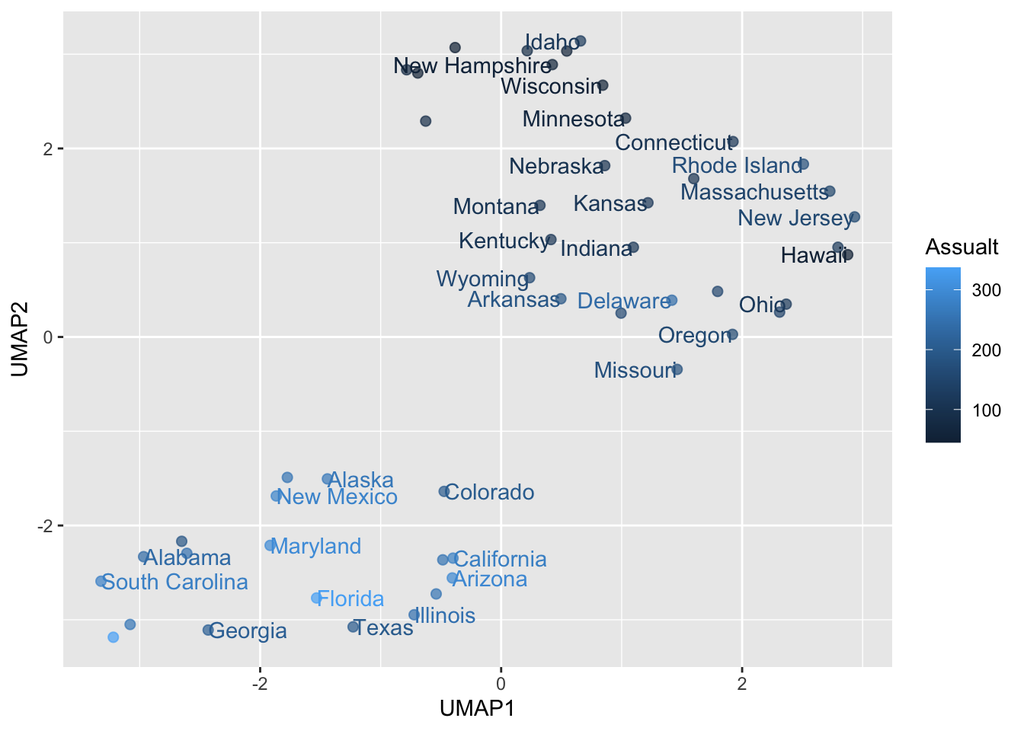

```r
set.seed(211)
umap_rec <- recipe(~., data = USArrests) %>%
  update_role(State, new_role = "id") %>%
  step_normalize(all_predictors()) %>%
  step_umap(all_predictors(),
            neighbors = 10,
            num_comp = 2,
            min_dist = 0.01)

umap_prep <- prep(umap_rec)

Assault = umap_prep$template %>% merge(USArrests, by = "State") %>% pull(Assault)
juice(umap_prep) %>%
  ggplot(aes(UMAP1, UMAP2, label = State, color = Assault)) +
  geom_point( alpha = 0.7, size = 2) +
  geom_text(check_overlap = TRUE, hjust = "inward") +
  labs(color = "Assualt")
```

- MNIST and Fashion MNIST

```r
# may take sometime
fashion_mnist <- dataset_fashion_mnist()
mnist <- dataset_mnist()
```

```r
# c(train_images, train_labels) %<-% fashion_mnist$train
# c(test_images, test_labels) %<-% fashion_mnist$test

c(train_images, train_labels) %<-% mnist$train
c(test_images, test_labels) %<-% mnist$test
```

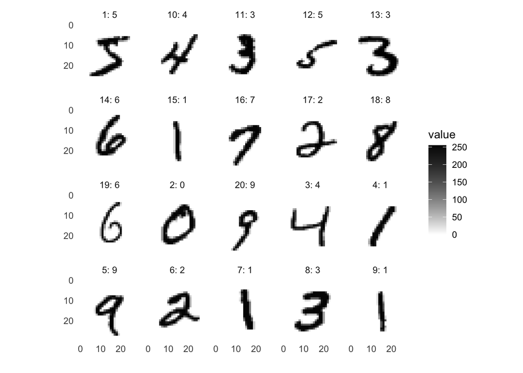

```r
sample_image <- tibble()
for(i in 1:20){
  image <- as.data.frame(train_images[i, , ])
  colnames(image) <- seq_len(ncol(image))
  image <- image  %>%
    mutate(y = seq_len(nrow(image)))
  image <- gather(image, "x", "value", -y)
  image <- image %>%
    as_tibble() %>%
    mutate(x = as.integer(x),
           l = paste(i, ": ", as.character(train_labels[i]), sep = ""))
  sample_image <- bind_rows(sample_image, image)
}


p <- ggplot(sample_image, aes(x = x, y = y, fill = value)) +
    geom_tile() + scale_fill_gradient(low = "white", high = "black", na.value = NA) +
    scale_y_reverse() + theme_minimal() + theme(panel.grid = element_blank()) +
    theme(aspect.ratio = 1) + xlab("") + ylab("")  +
    facet_wrap(~l, ncol = 5)
print(p)
```

#### 3.3.1 PCA

```r
train_images <- array_reshape(train_images, c(nrow(train_images), 784))
train_images <- train_images / 255

set.seed(211)
n = 1000
labels = as.factor(train_labels[1:n])
```

```r
pca_rec <- recipe(~., data = train_images[1:n, ]) %>%
  step_zv(all_numeric_predictors()) %>%
  step_normalize(all_predictors()) %>%
  step_pca(all_predictors())
pca_prep <- prep(pca_rec)
pca_prep
```

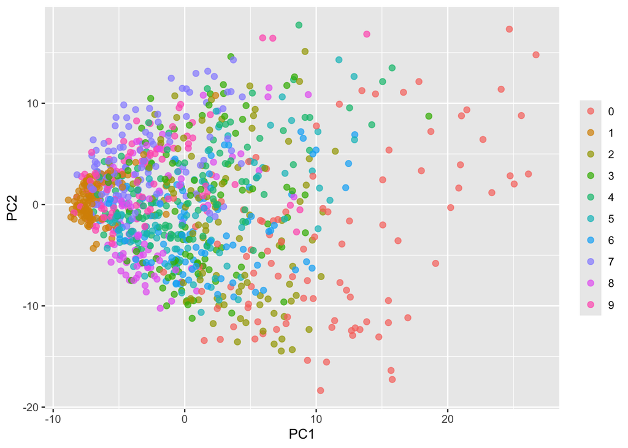

```r
juice(pca_prep) %>%
  ggplot(aes(PC1, PC2, label = labels)) +
  geom_point(aes(color = labels), alpha = 0.7, size = 2) +
  #geom_text(check_overlap = TRUE, hjust = "inward") +
  labs(color = NULL)
```

#### 3.3.2 UMAP

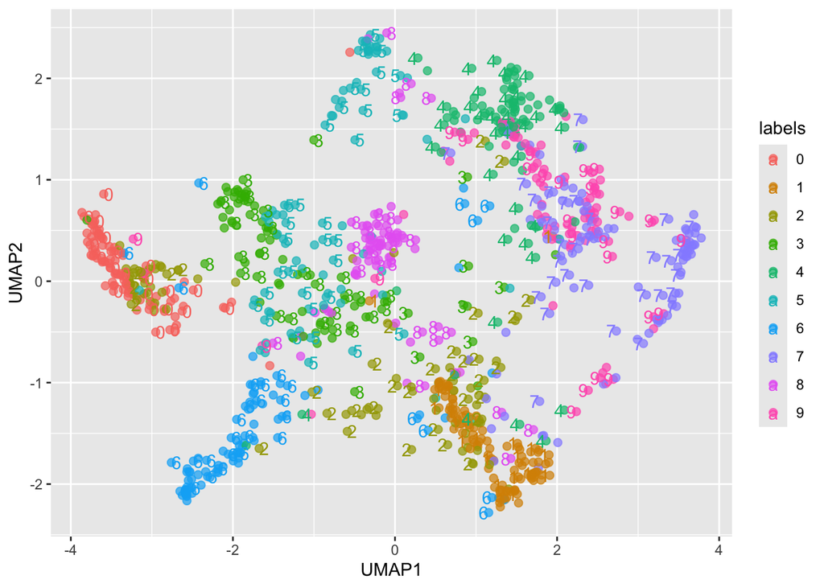

```r
umap_rec <- recipe(~., data = train_images[1:n, ]) %>%
  # update_role(State, new_role = "id") %>%
  step_zv(all_numeric_predictors()) %>%
  step_normalize(all_predictors()) %>%

  step_umap(all_predictors(),
            neighbors = 20,
            num_comp = 3,
            min_dist = 0.02)

umap_prep <- prep(umap_rec)

juice(umap_prep) %>%
  ggplot(aes(UMAP1, UMAP2, label = labels, color = labels)) +
  geom_point( alpha = 0.7, size = 2) +
  geom_text(check_overlap = TRUE, hjust = "inward")
```

### 3.4 A brief introduction to UMAP theory

[Fashion-MNIST](https://github.com/zalandoresearch/fashion-mnist)

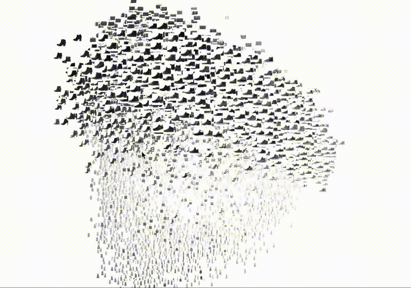

- First, UMAP constructs a high dimensional graph representation of the data using fuzzy simplicial complex:
  - a representation of a weighted graph, with edge weights representing the likelihood that two points are connected

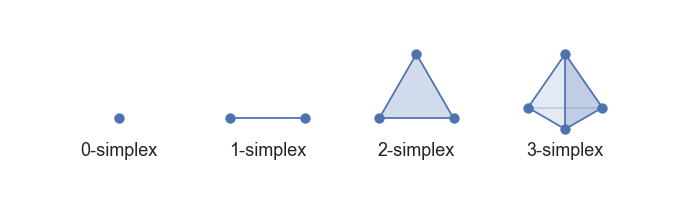

Figure 6: [Low dimensional simplices](https://umap-learn.readthedocs.io/en/latest/how_umap_works.html#id2)

- To determine connectedness, UMAP extends a radius outwards from each point, connecting points when those radii overlap. For example, consider a test dataset like this

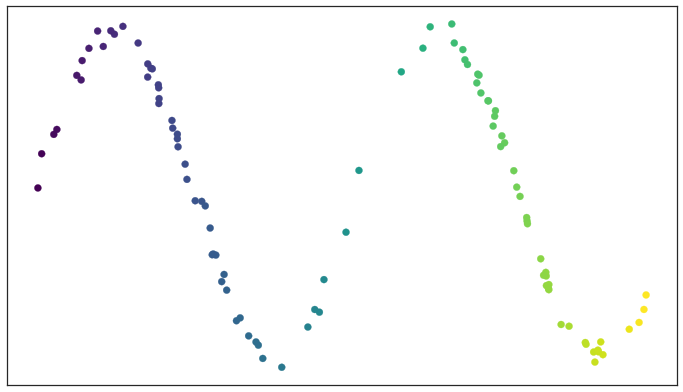

Figure 7: [Test data set of a noisy sine wave](https://umap-learn.readthedocs.io/en/latest/how_umap_works.html#id3)

- Then the result is something like this

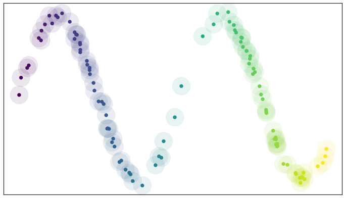

Figure 8: [A basic open cover of the test data](https://umap-learn.readthedocs.io/en/latest/how_umap_works.html#id4)

- We can then depict the the simplicial complex of 0-, 1-, and 2-simplices as points, lines, and triangles.

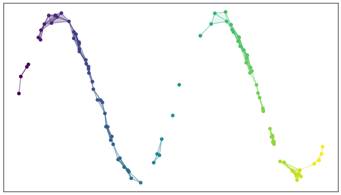

Figure 9: [A simplicial complex built from the test data](https://umap-learn.readthedocs.io/en/latest/how_umap_works.html#id5)

- Choosing this radius is critical - too small a choice will lead to small, isolated clusters, while too large a choice will connect everything together.
- UMAP overcomes this challenge by choosing a radius locally, based on the distance to each point’s nth nearest neighbor, i.e., `n_neighbors`.
- UMAP then makes the graph “fuzzy” by decreasing the likelihood of connection as the radius grows.
- By stipulating that each point must be connected to at least its closest neighbor, UMAP ensures that local structure is preserved in balance with global structure.
- Then, UMAP optimizes a low-dimensional graph to be as structurally similar as possible by controlling the number of edges and their weights.
- The second parameter we’ll investigate is `min_dist`, or the minimum distance between points in low-dimensional space. This parameter controls how tightly UMAP clumps points together, with low values leading to more tightly packed embeddings. Larger values of min_dist will make UMAP pack points together more loosely, focusing instead on the preservation of the broad topological structure.

#### 3.4.1 Try UMAP with different `n_neighbors` and `min_dist`

- Let’s try: https://pair-code.github.io/understanding-umap/

## 4 Clustering

- PCA looks for a low-dimensional representation of the observations that explains a good fraction of the variance.
- Clustering looks for homogeneous subgroups among the observations.

### 4.1 Two clustering methods

- In **K-means clustering**, we seek to partition the observations into a pre-specified number of clusters.
- In **hierarchical clustering**, we do not know in advance how many clusters we want; in fact, we end up with a tree-like visual representation of the observations, called a **dendrogram**, that allows us to view at once the clusterings obtained for each possible number of clusters, from 1 to $n$.

### 4.2 K-means clustering

[figure not shown]

- Let $C_1,\ldots,C_K$ denote sets containing the indices of the observations in each cluster. These sets satisfy two properties:
  1. $C_1 \cup C_2 \cup \ldots \cup C_K = \{1,\ldots,n\}$. In other words, each observation belongs to at least one of the $K$ clusters.
  2. $C_k \cap C_{k'} = \emptyset$ for all $k \ne k'$. In other words, the clusters are non-overlapping: no observation belongs to more than one cluster.

  For instance, if the $i$th observation is in the $k$th cluster, then $i \in C_k$.
- The idea behind $K$-means clustering is that a **good** clustering is one for which the **within-cluster variation** is as small as possible.
- The within-cluster variation for cluster $C_k$ is a measure WCV($C_k$) of the amount by which the observations within a cluster differ from each other.
- Hence we want to solve the problem
  $$\min_{C_1,\ldots,C_K} \left\{ \sum_{i=1}^K \text{WCV}(C_k) \right\}.$$
  In words, this formula says that we want to partition the observations into $K$ clusters such that the total within-cluster variation, summed over all $K$ clusters, is as small as possible.
- Typically we use Euclidean distance
  $$\text{WCV}(C_k) = \frac{1}{|C_k|} \sum_{i, i' \in C_k} \sum_{j=1}^p (x_{ij} - x_{i'j})^2,$$
  where $|C_k|$ denotes the number of observations in the $k$th cluster.
- Therefore the optimization problem that defines $K$-means clustering is
  $$\min_{C_1,\ldots,C_K} \left\{ \sum_{i=1}^K \frac{1}{|C_k|} \sum_{i, i' \in C_k} \sum_{j=1}^p (x_{ij} - x_{i'j})^2 \right\}.$$
- $K$-means clustering algorithm:
  1. Randomly assign a number, from 1 to $K$, to each of the observations. These serve as initial cluster assignments for the observations
  2. Iterate until the cluster assignments stop changing:

     2.a. For each of the $K$ clusters, compute the cluster **centroid**. The $k$th cluster centroid is the vector of the $p$ feature means for the observations in the $k$th cluster.

     2.b. Assign each observation to the cluster whose centroid is closest (where **closest** is defined using Euclidean distance).
- This algorithm is guaranteed to decrease the value of the objective at each step. Why? Note that
  $$\frac{1}{|C_k|} \sum_{i, i' \in C_k} \sum_{j=1}^p (x_{ij} - x_{i'j})^2 = 2 \sum_{i \in C_k} \sum_{j=1}^p (x_{ij} - \bar{x}_{kj})^2,$$
  where $\bar{x}_{kj} = \frac{1}{|C_k|} \sum_{i \in C_k} x_{ij}$ is the mean for for feature $j$ in cluster $C_k$. However it is not guaranteed to give the global minimum.

[figure not shown]

- Different staring values.

[figure not shown]

### 4.3 Hierarchical clustering

- $K$-means clustering requires us to pre-specify the number of clusters $K$. This can be a disadvantage (later we discuss strategies for choosing $K$).
- **Hierarchical clustering** is an alternative approach which does not require that we commit to a particular choice of $K$.
- We describe **bottom-up** or **agglomerative** clustering. This is the most common type of hierarchical clustering, and refers to the fact that a dendrogram is built starting from the leaves and combining clusters up to the trunk.
- Hierarchical clustering algorithm
  - Start with each point in its own cluster.
  - Identify the closest two clusters and merge them.
  - Repeat.
  - Ends when all points are in a single cluster.
- An example.

[figure not shown]

45 observations generated in 2-dimensional space. In reality there are three distinct classes, shown in separate colors. However, we will treat these class labels as unknown and will seek to cluster the observations in order to discover the classes from the data.

[figure not shown]

Left: Dendrogram obtained from hierarchically clustering the data from previous slide, with complete linkage and Euclidean distance. Center: The dendrogram from the left-hand panel, cut at a height of 9 (indicated by the dashed line). This cut results in two distinct clusters, shown in different colors. Right: The dendrogram from the left-hand panel, now cut at a height of 5. This cut results in three distinct clusters, shown in different colors. Note that the colors were not used in clustering, but are simply used for display purposes in this figure.

- Types of linkage.

| *Linkage* | *Description* |
| --- | --- |
| Complete | Maximal inter-cluster dissimilarity. Compute all pairwise dissimilarities between the observations in cluster A and the observations in cluster B, and record the **largest** of these dissimilarities. |
| Single | Minimal inter-cluster dissimilarity. Compute all pairwise dissimilarities between the observations in cluster A and the observations in cluster B, and record the **smallest** of these dissimilarities. |
| Average | Mean inter-cluster dissimilarity. Compute all pairwise dissimilarities between the observations in cluster A and the observations in cluster B, and record the **average** of these dissimilarities. |
| Centroid | Dissimilarity between the centroid for cluster A (a mean vector of length $p$) and the centroid for cluster B. Centroid linkage can result in undesirable **inversions**. |

- Choice of dissimilarity measure.
  - So far have used Euclidean distance.
  - An alternative is **correlation-based distance** which considers two observations to be similar if their features are highly correlated.
- Practical issues.
  - Scaling of the variables matters!
  - What dissimilarity measure should be used?
  - What type of linkage should be used?
  - How many clusters to choose?
  - Which features should we use to drive the clustering?

## 5 Conclusions

- **Unsupervised learning** is important for understanding the variation and grouping structure of a set of unlabeled data, and can be a useful pre-processor for supervised learning.
- It is intrinsically more difficult than **supervised learning** because there is no gold standard (like an outcome variable) and no single objective (like test set accuracy).
- It is an active field of research, with many recently developed tools such as **self-organizing maps**, **independent components analysis** (ICA) and **spectral clustering**. See ESL Chapter 14.